# Chinese Baseball Survey

2018년 9월 17일

## 0. 목차

1. 중국의 야구?
2. 중국의 야구 정책
3. 중국의 야구 발전
4. 세계 야구 산업 - 우리나라의 포지션
5. 결론
6. 참고

## 1. 중국의 야구?

## 1. 중국의 야구?

[figure not shown]

## 1. 중국의 야구?

- 중국 야구의 아버지 양푸추 - 1932년 야구 도입
- 문화대혁명으로 사라졌다가 1979년 야구 협회 생김
- 1985년 아시아 야구 연맹 가입
- 중국야구협회(CBAA) 주관
- 중국봉구연새(中國棒球聯賽, CBL) 2002년 창설

## 1. 중국의 야구?

### **CBL은?**

- 프로가 아닌 세미프로의 형식
- 1부 리그(갑), 2부 리그(을)로 나뉘어 짐
- 광둥 레오파즈, 장쑤 호프스타즈, 상하이 골든이글스 등
- 정규시즌
  - 연 경기수는 약 72경기
  - 3월에서 6월 진행
- 포스트시즌
  - 각 지구 1위팀이 타 지구 2위팀과 플레이오프
  - 챔피언쉽 시리즈 5판 3선승제

## 1. 중국의 야구?

- 고등학교 야구 팀 50여개
- 유소년 리틀 야구
- A, AA, AAA급으로 나뉘어 대회 개최

## 1. 중국의 야구?

| 1994 | 히로시마 아시안게임 | 4강 |
| --- | --- | --- |
| 1998 | 방콕 아시안게임 | 4강 |
| 2002 | 부산 아시안게임 | 4강 |
| 2006 | 도하 아시안게임 | 4강 |
| 2006 | WBC | 15위 |
| 2008 | 베이징 올림픽 | 8위 |

## 1. 중국의 야구?

| 2009 | WBC | 11위 |
| --- | --- | --- |
| 2010 | 광저우 아시안게임 | 4강 |
| 2013 | WBC | 13위 |
| 2014 | 인천 아시안게임 | 4강 |
| 2017 | WBC | 16위 |
| 2018 | 자카, 팔렘방 아시안게임 | 4강 |

- 2008 베이징 올림픽 대만에게 승리
- 2009 WBC 대만에게 승리
- 아시아 시리즈에 참여하기도

## 2. 중국의 야구 정책

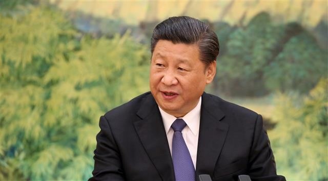

## 2. 중국의 야구 정책

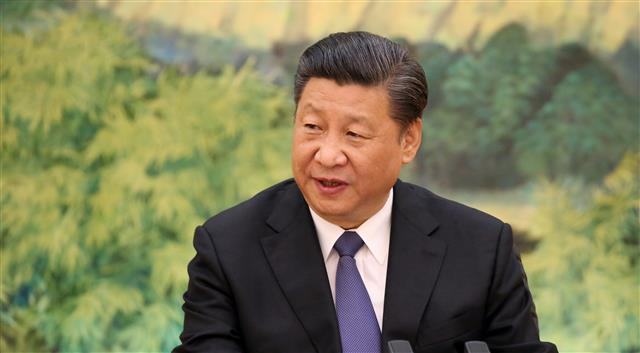

시진핑 曰

"스포츠 산업을 2025년까지 5조 위안 규모로 키우겠다"

**야구도 2500만 위안 (약 43조)**

## 2. 중국의 야구 정책

### **10 + 6 플랜**

- 2014년 중국 야구 리그 부활
- 5년 동안의 중국 야구 프로화 계획
- 메인 스폰서와의 협력(헝다 그룹)

## 3. 중국의 야구 발전

- 90년대 말부터 메이저리그 사무국의 투자
  - 현재는 베이징 국영 부동산 그룹과 10년 파트너십 계약
  - 중국 교육 텔레비전(CETV)과 중계권 계약
  - 야구 쇼 '메이저리그 야구 공원'
- 아마추어 야구팀 수 2013년 800개 -> 2015년 3000개
- 대학 야구팀 2012년 40개 미만 -> 현재 80여개
- 대만과의 양안교류전도 꾸준히 이어지고있음
- 2012년부터 NBO라는 대회도 이루어지고있음
- 미국 독립리그 '텍사스 에어호그스' - 올림픽 준비
- **2021년 프로리그 출범, 2025년까지 20개 구단**

## 3. 중국의 야구 발전 - 구글, 바이두 검색

### **[구글]**

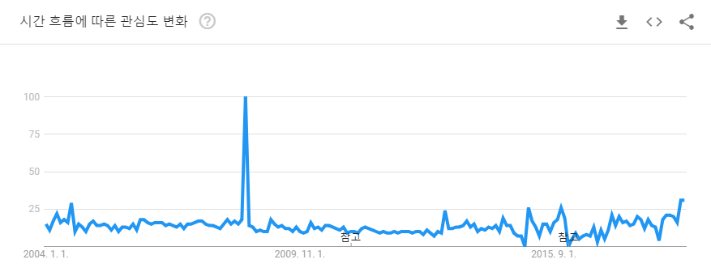

## 3. 중국의 야구 발전 - 구글, 바이두 검색

### **[구글]**

- 최근 5년간 '棒球' 검색량

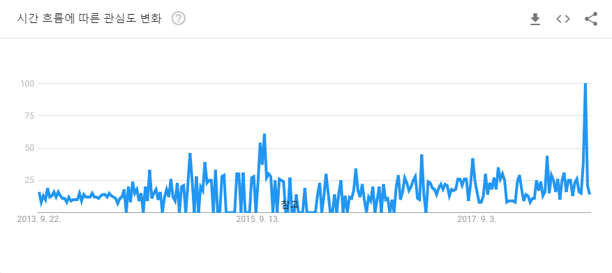

## 3. 중국의 야구 발전 - 구글, 바이두 검색

### **[구글]**

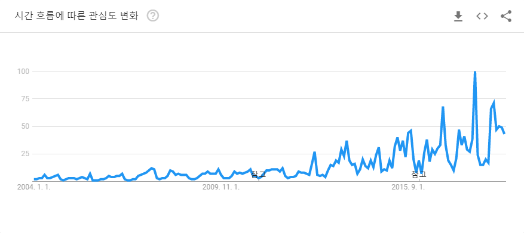

## 3. 중국의 야구 발전 - 구글, 바이두 검색

### **[구글]**

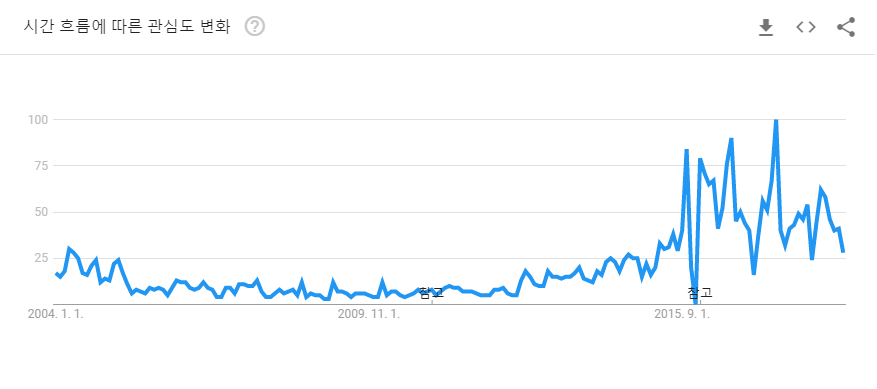

## 3. 중국의 야구 발전 - 구글, 바이두 검색

### **[바이두]**

- 2011년 이후 '棒球', 'MLB', 'baseball' 검색량

[figure not shown]

## 4. 세계 야구 산업 - 우리나라의 포지션

- 중국으로 떠나는 지도자들
  - 2021년 프로야구 출범 계획
  - 국내 프로야구 선수 출신들 지도자로 다수 중국 진출
- 심판 2만명과 코치 6천명
  - KBO와 CBAA 업무협약 당시 요청

## 4. 세계 야구 산업 - 우리나라의 포지션

- 2016년 KBO와 중국봉구협회 및 헝다 연합간의 업무협약
  - 2016년 구본능의 중국야구리그 개막식 참석
  - 중국에서 먼저 제안

## 5. 결론

- 병역 면제 관련하여 흥행 직격탄 맞은 우리나라
  - 일본은 일찍부터 CBL 후원
  - 중국 등 여러나라와 교류하며 저변 확대 필요
- MLB 평균 시청 연령 57세(NBA 42세, NFL 50세)
  - 중국에서 ‘야구는 고급 스포츠’라는 분위기가 만들어지는 중
  - 중국 농구의 흥행으로 큰 이득을 본 NBA
  - 야구의 세계화에 노력

## 6. 참고

- https://sports.news.naver.com/kbaseball/news/read.nhn?oid=076&aid=0002938690
- http://www.hankookilbo.com/News/Read/201707020761609229
- http://news.donga.com/3/all/20160428/77821852/1
- https://www.voakorea.com/a/4205205.html
- http://imnews.imbc.com/news/2016/sports/article/3979267_19811.html
- http://weekly.donga.com/List/3/09/11/1446769/1
- https://namu.wiki/w/중국봉구연새
- https://ko.wikipedia.org/wiki/중국야구리그
- http://baseball.sport.org.cn/
- https://news.joins.com/article/22549124